# Part II - FIFA Player Ability Analysis

## by Benjamin Mahagwa

## Investigation Overview

The goal of this presentation is to convey key insights from my analysis of the FIFA data. I got multiple insights from the data which are documented in the part 1. However, here I'll present the two key insights which I found interesting:

## Dataset Overview

> The dataset that I investigated consisted of data of different players in the popular FIFA game. The stats provided and information on the players reflects their real life abilities and performance in the game of football. The dataset consists of 18207 rows and 89 columns.

## Countries with the most players

From the plot below, we see that the highest number of players come from England. In the top ten countries with the highest number of players, we see that six are from Europe with the top three being England, Germany and Spain. Argentina comes in fourth, Brazil sixth and Colombia eigth as the countries from South America. Then we have Japan in ninth as the only Asian country in the top ten. We see France, Italy and Netherlands as the other European countries in the list.

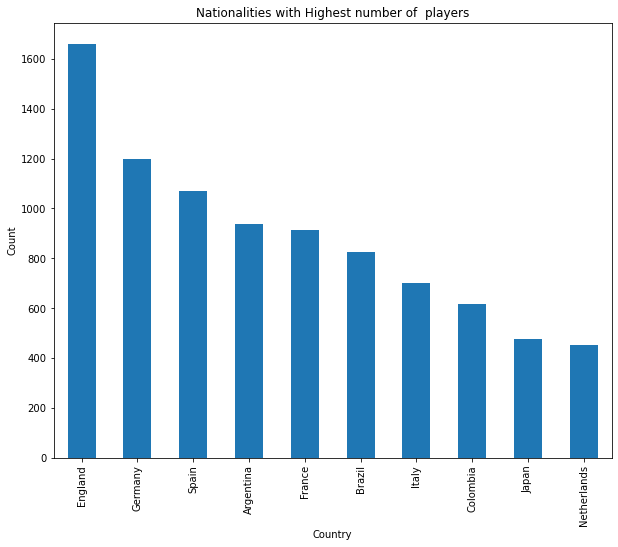

## Player Age Distribution

From the plot below derived from the data, we see a high number of players' ages are between the range of 19 and 28 years. The highest number of players being of age 21. We also see the youngest player being of age 16 and the oldest being above 41. Players aged 26 and 24 come at second and third highest respectively.

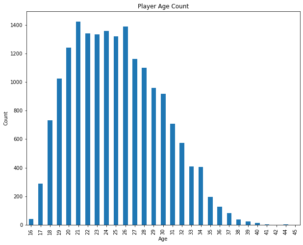

## Relationship between Age, Agility and Stamina

In the plot, we see a correlation between Stamina and Agility where players with lower agility also have lower stamina. We also see players above 35 generally having lower stamina. Players with higher Agility generally have higher Stamina too showing that the two are partially co-dependent variables.

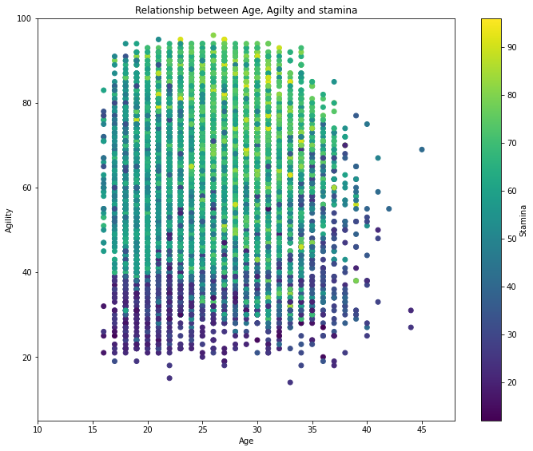